# R Notebook

# Setup

## Libraries

```r
quiet <- suppressPackageStartupMessages
quiet(library(tidyverse))
quiet(library(janitor))
quiet(library(limma))
quiet(library(openxlsx))
quiet(library(NormalyzerDE))
quiet(library(ProteinRollup))
quiet(library(ggpubr))
quiet(library(furrr))
quiet(library(edgeR))

plan(multisession)
theme_set(theme_classic())
```

## Utility functions

```r
setup_contrast_object <- function(name, base, levels, formula_string) {
  my_contrasts <- list(levels)
  names(my_contrasts) <- c(name)
  model <- as.formula(formula_string)

  my_contrasts_parsed <- lapply(my_contrasts, function(contrast) {
    paste(paste0(base, contrast), collapse="-")
  }) %>% unlist()

  list(
    name=name,
    model=model,
    contrasts=my_contrasts_parsed,
    group_col=base
  )
}

calculate_limma_results <- function(rdf, ddf, sample_names, contrast_objs) {

    calculate_limma_contrast <- function(stat_obj, sdf, ddf) {

        model <- as.formula(stat_obj$model)
        model_design <- model.matrix(model, data=ddf)
        fit <- limma::lmFit(sdf, model_design)
        contrasts <- stat_obj$contrasts
        contrast.matrix <- limma::makeContrasts(contrasts=contrasts, levels=model_design)
        fit_contrasts <- contrasts.fit(fit, contrast.matrix)
        fit_bayes <- limma::eBayes(fit_contrasts)
        limma_tables <- lapply(
            seq_len(length(colnames(fit_bayes$coefficients))),
                function(coef) { topTable(fit_bayes, coef=coef, number=Inf, sort.by="none", confint = TRUE) }
        )
        names(limma_tables) <- names(contrasts)
        combined_limma_tables <- do.call("cbind", limma_tables)
        combined_limma_tables
    }

    sdm <- rdf %>% dplyr::select(all_of(sample_names)) %>% as.matrix()
    adf <- rdf %>% dplyr::select(-any_of(sample_names))
    stat_results_table <- lapply(contrast_objs, calculate_limma_contrast, sdf=sdm, ddf=ddf) %>% do.call("cbind", .)
    rdf_stat <- cbind(adf, stat_results_table, sdm)
    rdf_stat
}

calculate_normalyzerde_stats <- function(rdf, ddf, samples, contrasts, cond_col, covariate=NULL, least_rep_count=1) {
  se <- SummarizedExperiment::SummarizedExperiment(
    assay = rdf %>% dplyr::select(all_of(samples)) %>% as.matrix(),
    rowData = rdf %>% dplyr::select(-one_of(samples)),
    colData = ddf
  )
  nst <- NormalyzerStatistics(se, logTrans=FALSE)
  nst_w_contrasts <- calculateContrasts(
    nst,
    contrasts,
    condCol=cond_col,
    batchCol = covariate,
    leastRepCount = least_rep_count)

  generateAnnotatedMatrix(
    nst_w_contrasts,
    prefixSep=".",
    compLabels=names(contrasts)
  )
}
```

# Multiomics dataset

Based on the study “Proteogenomic Characterization of Endometrial Carcinoma” (doi: https://doi.org/10.1016/j.cell.2020.01.026).

The data is retrieved from the supplementary materials in this article. The database with human proteins is retrieved from Uniprot.

Prior processing of datasets (according to the study):

- Proteomics: Global proteomics data, median polishing and log2 transformed, no missing value filtering
- RNA-seq: Linear gene expression RSEM, upper quantile normalized and log2(+1) transformed

## Load data

### File paths

```r
uniprot_human_fp <- "input_data/dbs/homo_sapiens_uniprot.tab.gz"
mo_proteomics_fp <- "input_data/2_multiomics/proteomics_rdf.tsv.gz"
mo_rna_fp <- "input_data/2_multiomics/rna_rdf.tsv.gz"
mo_ddf_fp <- "input_data/2_multiomics/mmc1.tsv"
```

### Databases

```r
uniprot_annot_df <- read_tsv(uniprot_human_fp) %>% janitor::clean_names()
uniprot_annot_df %>% colnames()
```

```
##  [1] "entry"                      "entry_name"
##  [3] "status"                     "protein_names"
##  [5] "gene_names"                 "organism"
##  [7] "length"                     "cross_reference_ne_xt_prot"
##  [9] "ensembl_transcript"         "cross_reference_gene_id"
```

### Data loading

```r
moo <- list()
moo$rdf_prot <- read_tsv(mo_proteomics_fp)
moo$rdf_rna <- read_tsv(mo_rna_fp, na="0")
moo_joint_colnames <- intersect(colnames(moo$rdf_prot), colnames(moo$rdf_rna))

moo$ddf_raw <- read_tsv(mo_ddf_fp) %>%
    filter(idx %in% moo_joint_colnames) %>%
    tidyr::replace_na(list(Genomics_subtype="Normal"))
moo$ddf <- moo$ddf_raw %>%
    dplyr::filter(Case_excluded == "No") %>%
    dplyr::filter(Proteomics_Tumor_Normal != "Adjacent_normal") %>%
    dplyr::mutate(Genomics_subtype = Genomics_subtype %>% gsub("-", "_", .) %>% tolower()) %>%
    dplyr::select(idx, Genomics_subtype, everything())

moo$samples_raw <- moo$ddf_raw$idx
moo$samples <- moo$ddf$idx
```

Check of numbers in each category - matches manuscript notes.

```r
moo$ddf$Genomics_subtype %>% table()
```

```
## .
## cnv_high  cnv_low    msi_h     pole
##       20       43       25        7
```

## Analysis

### Distribution check

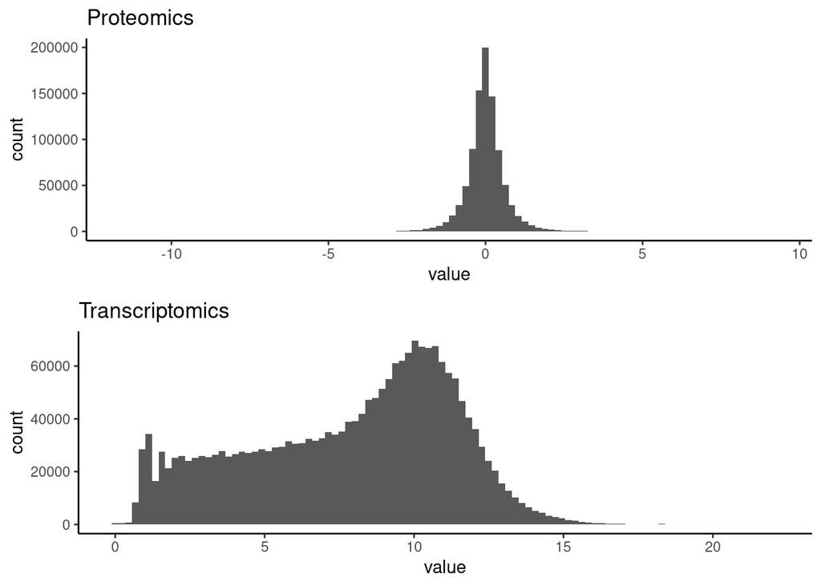

```r
ggarrange(
  moo$rdf_prot %>% dplyr::select(moo$samples) %>% pivot_longer(everything()) %>%
      ggplot(aes(x=value)) + geom_histogram(bins=100, na.rm = TRUE) + ggtitle("Proteomics"),
  moo$rdf_rna %>% dplyr::select(moo$samples) %>% pivot_longer(everything()) %>%
      ggplot(aes(x=value)) + geom_histogram(bins=100, na.rm = TRUE) + ggtitle("Transcriptomics"),
  nrow=2
)
```

### RNA-seq calculations

- Untransform log-transformed values (and minus-shift one)
- Filter low counts-per-million reads
- Calculate Voom

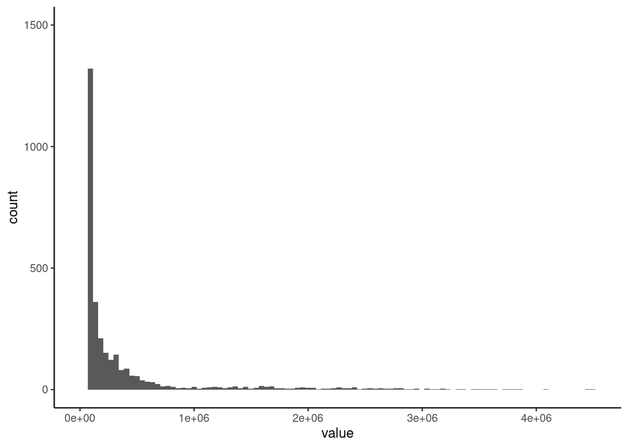

```r
unlog <- function(mat) {
    (2^mat)-1
}

rnaseqMatrix <- moo$rdf_rna %>% dplyr::select(moo$samples) %>% as.matrix() %>% unlog()
rnaseqMatrix %>% data.frame() %>% pivot_longer(everything()) %>% ggplot(aes(x=value)) + geom_histogram(bins=100) + xlim(1, NA) + ylim(0, 1500)
```

```r
# Filter lowly abundant rows
features_passing_cpm <- rowSums(edgeR::cpm(rnaseqMatrix %>% as.matrix() %>% replace_na(0)) >= 1) >= 6
cpm_filtered_matrix <- rnaseqMatrix[features_passing_cpm, ]
message(sprintf("Filtered %s perc of features", 100 * (1 - dim(cpm_filtered_matrix)[1] / dim(rnaseqMatrix)[1]) %>% round(4)))
```

```
## Filtered 31.89 perc of features
```

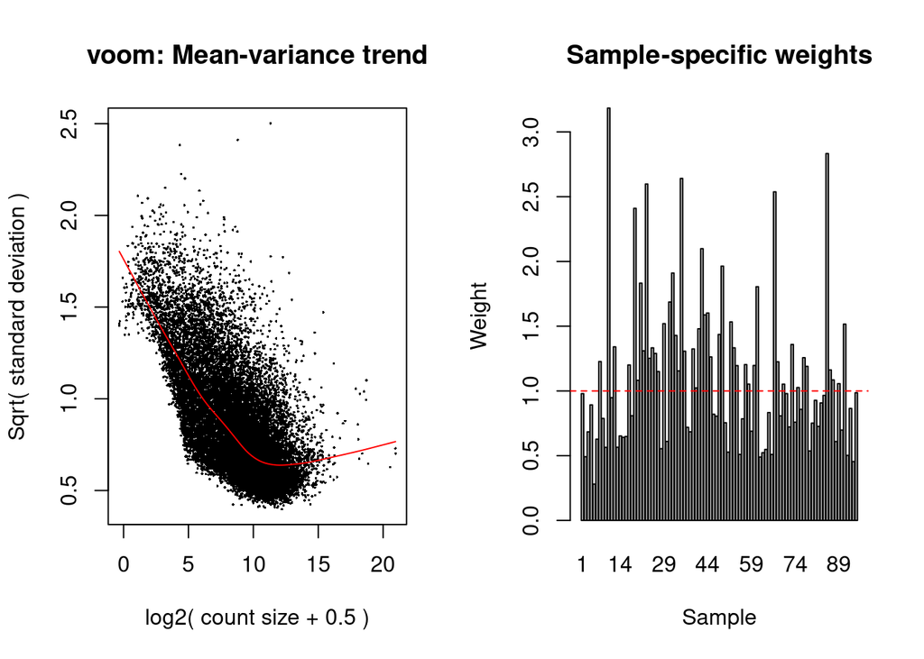

```r
# Create EdgeR DGEList object, replacing NAs with zeroes
DGE <- edgeR::DGEList(cpm_filtered_matrix %>% as.matrix() %>% replace_na(0))
# Calculate TMM normalization factors for counts
DGE <- edgeR::calcNormFactors(DGE, method = c("TMM"))

# Calculate Voom and Limma
design_temp <- model.matrix(~0+Genomics_subtype, data=moo$ddf %>% as.matrix() %>% replace_na("missing") %>% data.frame())
vwts <- voomWithQualityWeights(DGE, design=design_temp, normalize.method="none", plot=TRUE)
```

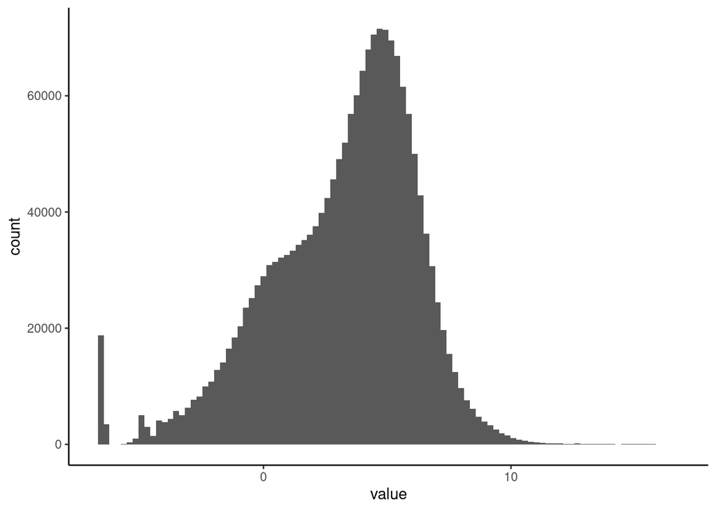

```r
# Check the distribution
vwts$E %>% data.frame() %>% pivot_longer(everything()) %>% ggplot(aes(x=value)) + geom_histogram(bins=100)
```

```r
# Calculate Limma
fit <- lmFit(vwts, design_temp)
contr <- makeContrasts(Genomics_subtypecnv_high-Genomics_subtypecnv_low, levels=colnames(coef(fit)))
contrast_fit <- contrasts.fit(fit, contr)
efit <- eBayes(contrast_fit, robust=TRUE)

# Retrieve toplist
moo_rna_stat_adf <- topTable(efit, adjust="BH", coef="Genomics_subtypecnv_high - Genomics_subtypecnv_low", number=Inf, sort.by = "none") %>%
    `colnames<-`(paste0("cnvhigh_cnvlow.", colnames(.)))
moo_rna_stat_adf %>% filter(cnvhigh_cnvlow.adj.P.Val < 0.05 & abs(cnvhigh_cnvlow.logFC) > 1)
```

|  | cnvhigh_cnvlow.logFC | cnvhigh_cnvlow.AveExpr | cnvhigh_cnvlow.t | cnvhigh_cnvlow.P.Value | cnvhigh_cnvlow.adj.P.Val | cnvhigh_cnvlow.B |
| --- | --- | --- | --- | --- | --- | --- |
| 7 | -1.106992 | 4.305102120 | -4.112245 | 8.395097e-05 | 1.023805e-03 | 0.980111821 |
| 12 | -1.627094 | -1.551294082 | -3.009203 | 3.361658e-03 | 1.658268e-02 | -1.834310090 |
| 14 | -1.259183 | -1.091780142 | -2.681682 | 8.652351e-03 | 3.389636e-02 | -2.606445505 |
| 98 | -1.087726 | 2.629858937 | -3.786280 | 2.693951e-04 | 2.481032e-03 | 0.127594986 |
| 138 | -1.072382 | 0.373077318 | -3.736542 | 3.199989e-04 | 2.812870e-03 | 0.153614665 |
| 149 | 1.177898 | -1.741085055 | 3.846015 | 2.183904e-04 | 2.129823e-03 | 0.488041222 |
| 169 | 1.670909 | -0.231792039 | 4.723722 | 8.089025e-06 | 1.704989e-04 | 3.466676334 |
| 170 | 1.427309 | -1.769649961 | 3.697158 | 3.665165e-04 | 3.123309e-03 | 0.039391563 |
| 178 | -1.482974 | -1.109718170 | -3.751294 | 3.040655e-04 | 2.712463e-03 | 0.158808133 |
| 184 | -1.926865 | 6.745230172 | -4.852198 | 4.844186e-06 | 1.158603e-04 | 3.510299238 |

[output cut: 1536 more lines]

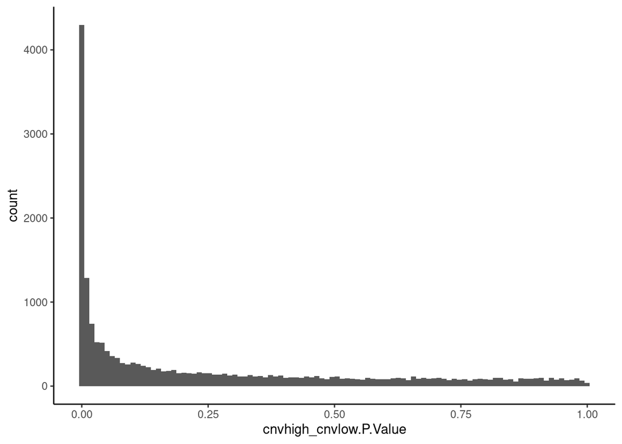

```r
moo_rna_stat_adf %>% ggplot(aes(x=cnvhigh_cnvlow.P.Value)) + geom_histogram(bins=100)
```

```r
moo$rdf_rna_w_stats <- cbind(
    idx=moo$rdf_rna$idx[features_passing_cpm],
    moo_rna_stat_adf,
    moo$rdf_rna[features_passing_cpm, ] %>% dplyr::select(moo$ddf$idx)
)

moo$rdf_rna_voom_w_stats <- cbind(
    idx=moo$rdf_rna$idx[features_passing_cpm],
    moo_rna_stat_adf,
    vwts$E %>% data.frame() %>% dplyr::select(moo$ddf$idx)
)
```

### Spotcheck differentially expressed features

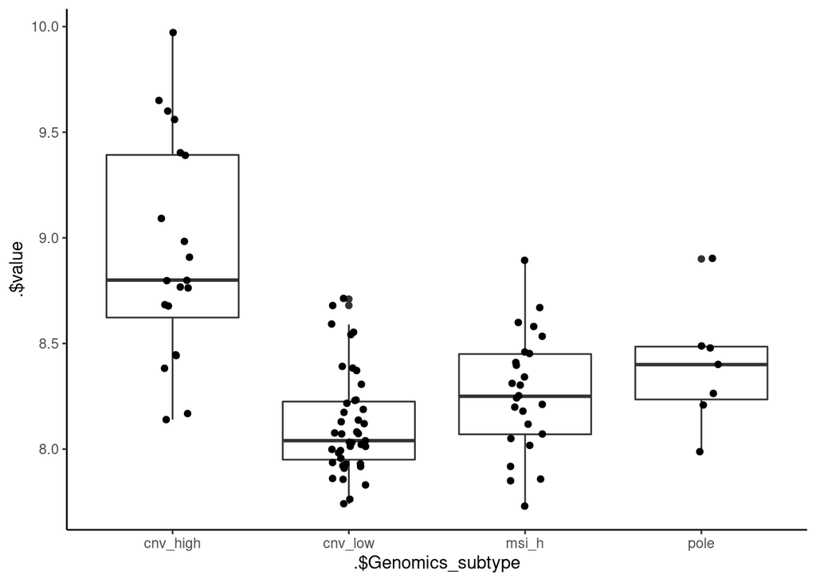

```r
moo$rdf_rna %>%
  filter(idx=="WDR53") %>%
  dplyr::select(all_of(moo$ddf$idx)) %>%
  t() %>%
  data.frame() %>%
  rownames_to_column("sample_name") %>%
  `colnames<-`(c("idx", "value")) %>%
  left_join(moo$ddf, by="idx") %>%
  ggplot(aes(x=.$Genomics_subtype, .$value)) + geom_boxplot() + geom_jitter(width=0.1)
```

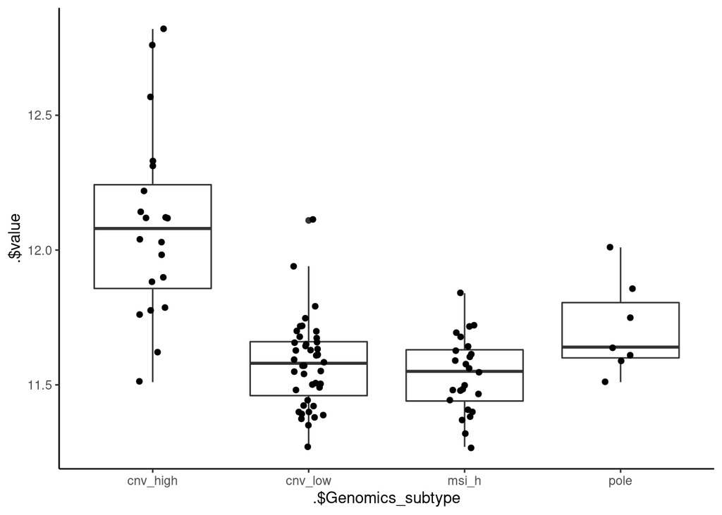

```r
moo$rdf_rna_w_stats %>%
  filter(idx=="SENP5") %>%
  dplyr::select(all_of(moo$ddf$idx)) %>%
  t() %>%
  data.frame() %>%
  rownames_to_column("sample_name") %>%
  `colnames<-`(c("idx", "value")) %>%
  left_join(moo$ddf, by="idx") %>%
  ggplot(aes(x=.$Genomics_subtype, .$value)) + geom_boxplot() + geom_jitter(width=0.1)
```

### Proteomics statistics

Already log transformed.

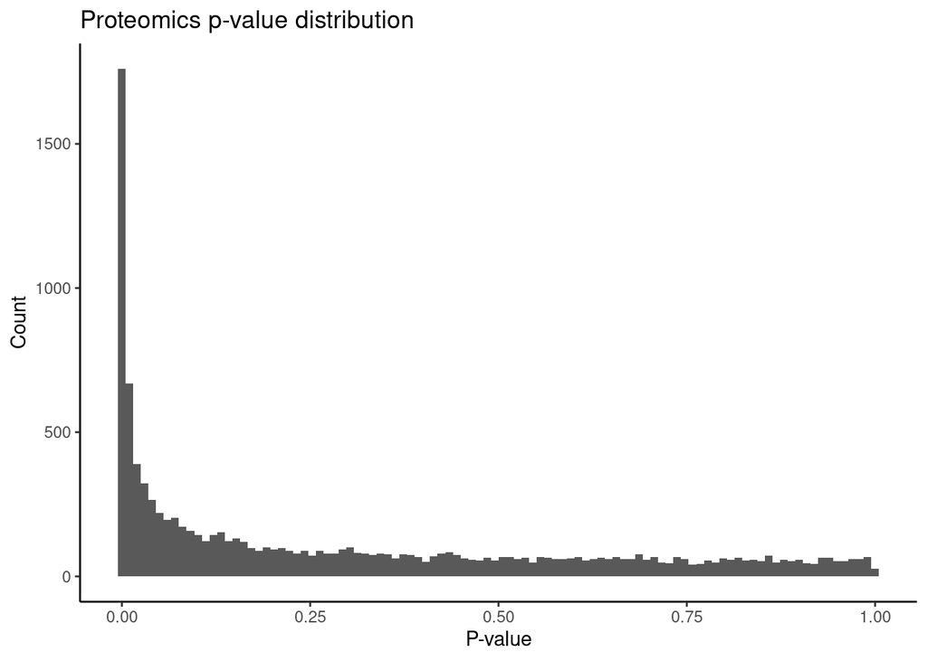

```r
moo$prot_rdf_stat <- calculate_normalyzerde_stats(
  moo$rdf_prot %>% dplyr::select(idx, all_of(moo$ddf$idx)),
  moo$ddf,
  moo$ddf$idx,
  c("cnv_high_low"="cnv_high-cnv_low"),
  cond_col="Genomics_subtype"
)

qplot(moo$prot_rdf_stat$cnv_high_low.PValue, bins=100, na.rm=TRUE) + xlab("P-value") + ylab("Count") + ggtitle("Proteomics p-value distribution")
```

## Output

```r
moo_out_base <- "output_data/multiomics"

dir.create(moo_out_base, recursive = TRUE)
write_tsv(moo$rdf_prot, path=sprintf("%s/prot_full.tsv", moo_out_base))
write_tsv(moo$prot_rdf_stat, path=sprintf("%s/prot_stats.tsv", moo_out_base))
write_tsv(moo$prot_rdf_stat %>% head(500), path=sprintf("%s/prot_stats_500.tsv", moo_out_base))

write_tsv(moo$rdf_rna, path=sprintf("%s/rna_full.tsv", moo_out_base))
write_tsv(moo$rdf_rna_w_stats, path=sprintf("%s/rna_stats.tsv", moo_out_base))
write_tsv(moo$rdf_rna_w_stats %>% head(500), path=sprintf("%s/rna_stats_500.tsv", moo_out_base))
write_tsv(moo$rdf_rna_voom_w_stats, path=sprintf("%s/rna_stats_voom.tsv", moo_out_base))

write_tsv(moo$ddf_raw %>% dplyr::select(idx, Genomics_subtype, everything()), path=sprintf("%s/design_full.tsv", moo_out_base))
write_tsv(moo$ddf %>% dplyr::select(idx, Genomics_subtype, everything()), path=sprintf("%s/design_stats.tsv", moo_out_base))
```

# Covid dataset: Proteomics

Based on the study “Proteomics of SARS-CoV-2-infected host cells reveals therapy targets” (doi: https://doi.org/10.1038/s41586-020-2332-7)

The data is retrieved from its supplementary, and converted into TSV format. The databases are retrieved from Uniprot.

## Load data

### File paths

```r
coo_proteomics_fp <- "input_data/3_covid/supplementary_table_02_prot.tsv"
coo_translatomics_fp <- "input_data/3_covid/supplementary_table_01_transl.tsv"
coo_ddf_fp <- "input_data/3_covid/covid_ddf.tsv"
virus_prots_fp <- "input_data/dbs/virus_ids_only.txt"
virus_prots_w_receptors <- "input_data/dbs/virus_related_ids.txt"
```

### Databases

```r
virus_ids <- read_tsv(virus_prots_fp, col_names = FALSE) %>% unlist() %>% unname()
virus_and_host_ids <- read_tsv(virus_prots_w_receptors, col_names = FALSE) %>% unlist() %>% unname()
message("Virus proteins")
```

```
## Virus proteins
```

```r
message(paste(virus_ids, collapse=", "))
```

```
## P0DTC1, P0DTC2, P0DTC3, P0DTC5, P0DTC6, P0DTC7, P0DTC8, P0DTC9, P0DTD2
```

```r
message("Virus proteins and receptors")
```

```
## Virus proteins and receptors
```

```r
message(paste(virus_and_host_ids, collapse=", "))
```

```
## O15393, O15393-2, O43765, P05231, P07711, P08887, P09958, P20701, P35232, P35613, P35613-2, P40189, P52292, P62937, P84022, Q10589, Q16552, Q8N3R9, Q8NAC3, Q8NHX9, Q92499, Q96F46, Q96PD4, Q99623, Q9BYF1, Q9Y2I7, P08887-2, P35613-3, P35613-4, P40189-2, Q8NAC3-5, Q8NAC3-6, Q8NAC3-7, Q8NAC3-8, P0771…
```

### Data loading

```r
coo <- list()
coo$rdf_prot <- read_tsv(coo_proteomics_fp, na = "0") %>%
    left_join(uniprot_annot_df %>% dplyr::select(entry, protein_names), by=c("UniProt.Accession"="entry")) %>%
    dplyr::select(UniProt.Accession, protein_names, everything())
coo$rdf_transl <- read_tsv(coo_translatomics_fp) %>%
    `colnames<-`(colnames(.) %>% make.names()) %>%
    left_join(uniprot_annot_df %>% dplyr::select(entry, protein_names), by=c("Accession"="entry")) %>%
    dplyr::select(Accession, protein_names, everything())
coo$ddf <- read_tsv(coo_ddf_fp)
coo$samples <- coo$ddf$sample

coo$rdf_prot$VirusType <- ifelse(coo$rdf_prot$UniProt.Accession %in% virus_and_host_ids, ifelse(coo$rdf_prot$UniProt.Accession %in% virus_ids, "virus", "virus_host"), "na")
coo$rdf_transl$VirusType <- ifelse(coo$rdf_transl$Accession %in% virus_and_host_ids, ifelse(coo$rdf_transl$Accession %in% virus_ids, "virus", "virus_host"), "na")
```

## Analysis

### Distribution check

Distribution after log transform

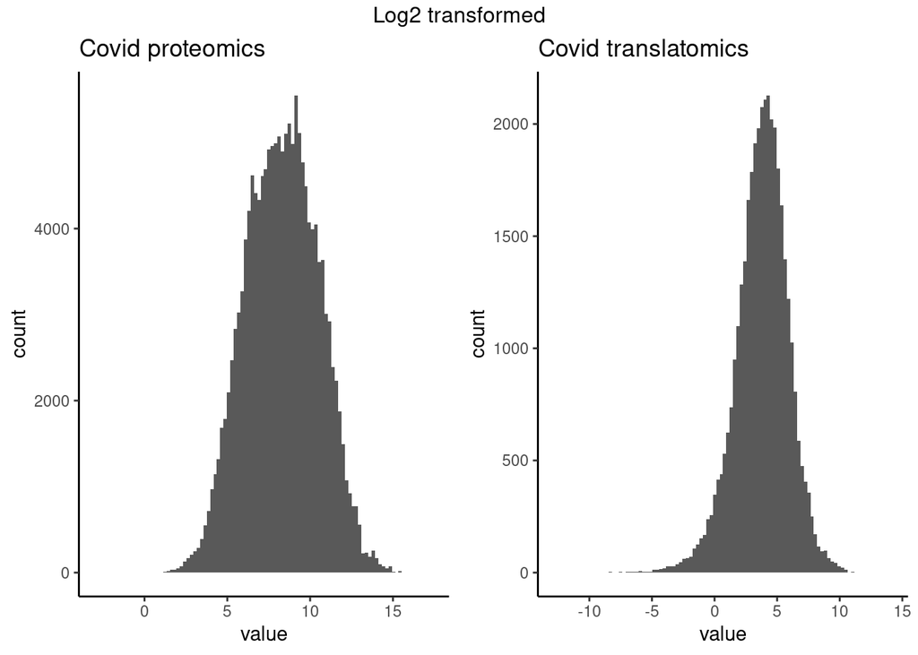

```r
ggarrange(
    coo$rdf_prot %>%
        dplyr::select(coo$samples) %>%
        log2() %>%
        pivot_longer(everything()) %>%
        ggplot(aes(x=value)) + geom_histogram(bins=100, na.rm = TRUE) + ggtitle("Covid proteomics"),
    coo$rdf_transl %>%
        dplyr::select(coo$samples) %>%
        log2() %>%
        # mutate_all(~.+10) %>%
        pivot_longer(everything()) %>%
        ggplot(aes(x=value)) + geom_histogram(bins=100, na.rm = TRUE) + ggtitle("Covid translatomics")
) %>% annotate_figure(top="Log2 transformed")
```

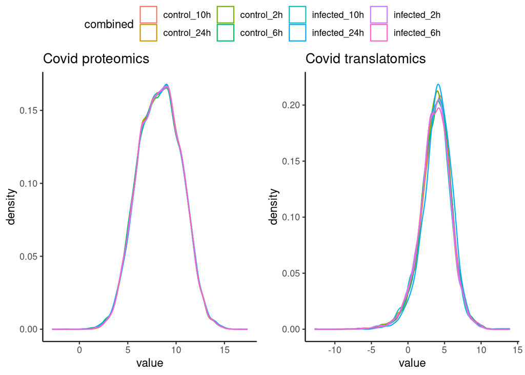

```r
ggarrange(
  coo$rdf_prot %>%
      dplyr::select(coo$samples) %>%
      log2() %>%
      pivot_longer(everything(), names_to="sample") %>%
      inner_join(coo$ddf, "sample") %>%
      ggplot(aes(x=value, color=combined)) + geom_density() + ggtitle("Covid proteomics"),
  coo$rdf_transl %>%
      dplyr::select(coo$samples) %>%
      log2() %>%
      pivot_longer(everything(), names_to="sample") %>%
      inner_join(coo$ddf, "sample") %>%
      ggplot(aes(x=value, color=combined)) + geom_density() + ggtitle("Covid translatomics"), common.legend = TRUE
)
```

### Normalization

A simple log2 transform seems to suffice.

```r
coo$sdm_prot <- coo$rdf_prot %>% dplyr::select(coo$samples) %>% as.matrix() %>% log2()
coo$rdf_prot_norm <- cbind(
  coo$rdf_prot %>% dplyr::select(-any_of(coo$ddf$sample)),
  coo$sdm
)

coo$sdm_transl <- coo$rdf_transl %>% dplyr::select(coo$samples) %>% as.matrix() %>% log2()
coo$rdf_transl_norm <- cbind(
  coo$rdf_transl %>% dplyr::select(-any_of(coo$ddf$sample)),
  coo$sdm_transl
)
```

### Statistical contrasts (Limma)

Prepare contrasts

```r
covid_contrasts <- c(
  "inf_ctl_2h"="infected_2h-control_2h",
  "inf_ctl_6h"="infected_6h-control_6h",
  "inf_ctl_10h"="infected_10h-control_10h",
  "inf_ctl_24h"="infected_24h-control_24h",
  "inf_6h_2h"="infected_6h-infected_2h",
  "inf_10h_2h"="infected_10h-infected_2h",
  "inf_24h_2h"="infected_24h-infected_2h",
  "ctl_6h_2h"="control_6h-control_2h",
  "ctl_10h_2h"="control_10h-control_2h",
  "ctl_24h_2h"="control_24h-control_2h"
)
covid_contrasts_w_cov <- covid_contrasts %>% `names<-`(names(covid_contrasts) %>% paste0(., "_wcov"))
```

Perform calculations

```r
coo$prot_rdf_stat_nocov <- calculate_normalyzerde_stats(coo$rdf_prot_norm, coo$ddf, coo$samples, covid_contrasts, cond_col="combined")
coo$prot_rdf_stat_cov <- calculate_normalyzerde_stats(coo$rdf_prot_norm, coo$ddf, coo$samples, covid_contrasts_w_cov, cond_col="combined", covariate="nbr")
prot_cov_spec_cols <- colnames(coo$prot_rdf_stat_cov)[!(colnames(coo$prot_rdf_stat_cov) %in% colnames(coo$prot_rdf_stat_nocov))]
coo$prot_rdf_stat <- cbind(
  coo$prot_rdf_stat_nocov,
  coo$prot_rdf_stat_cov %>% dplyr::select(all_of(prot_cov_spec_cols))
)

coo$transl_rdf_stat_nocov <- calculate_normalyzerde_stats(coo$rdf_transl_norm, coo$ddf, coo$samples, covid_contrasts, cond_col="combined")
coo$transl_rdf_stat_cov <- calculate_normalyzerde_stats(coo$rdf_transl_norm, coo$ddf, coo$samples, covid_contrasts_w_cov, cond_col="combined", covariate="nbr")
transl_cov_spec_cols <- colnames(coo$prot_rdf_stat_cov)[!(colnames(coo$prot_rdf_stat_cov) %in% colnames(coo$prot_rdf_stat_nocov))]
coo$transl_rdf_stat <- cbind(
  coo$transl_rdf_stat_nocov,
  coo$transl_rdf_stat_cov %>% dplyr::select(all_of(transl_cov_spec_cols))
)
```

## Output

```r
coo_basedir <- "output_data/covid"
dir.create("output_data/covid", recursive = TRUE)
write_tsv(coo$prot_rdf_stat, path=sprintf("%s/data_prot.tsv", coo_basedir))
write_tsv(coo$transl_rdf_stat, path=sprintf("%s/data_transl.tsv", coo_basedir))
write_tsv(coo$ddf, path=sprintf("%s/design_prot.tsv", coo_basedir))
```

# Covid dataset: RNA-seq

Based on article SARS-CoV-2 productively infects human gut enterocytes (Mart M Lamers, Science, 2020, doi: 10.1126/science.abc1669) The data is based on supplementary materials retrieved from: https://www.ncbi.nlm.nih.gov/geo/query/acc.cgi?acc=GSE149312

According to the description, the data contains UMI deduplicated counts normalized between samples.

- UMI (unique molecular identifier) count: Absolute number of observed transcripts, alternative to read counting? Negative binomial good fit?

## Process expression data

```r
sarscov2_ddf <- read_tsv("input_data/3_covid_2/covid_expression_ddf.tsv")
sarscov2_rdf <- read_csv("input_data/3_covid_2/GSE149312_corona_intestine_exp1_ndata.csv")
head(sarscov2_ddf)
```

| sample | medium | type | time | medium_type_time | description |
| --- | --- | --- | --- | --- | --- |
| s1_1 | differentiation | control | NA | differentiation_control_NA | Bulk RNA sequencing of human intestinal organoid, in differentiation medium. |
| s1_2 | differentiation | control | NA | differentiation_control_NA | Bulk RNA sequencing of human intestinal organoid, in differentiation medium. |
| s1b24_1 | differentiation | sarscov2 | 24h | differentiation_sarscov2_24h | Bulk RNA sequencing of human intestinal organoid, in differentiation medium, 24 hours after SARS-CoV2 infection. |
| s1b24_2 | differentiation | sarscov2 | 24h | differentiation_sarscov2_24h | Bulk RNA sequencing of human intestinal organoid, in differentiation medium, 24 hours after SARS-CoV2 infection. |
| s1b60_1 | differentiation | sarscov2 | 60h | differentiation_sarscov2_60h | Bulk RNA sequencing of human intestinal organoid, in differentiation medium, 60 hours after SARS-CoV2 infection. |
| s1b60_2 | differentiation | sarscov2 | 60h | differentiation_sarscov2_60h | Bulk RNA sequencing of human intestinal organoid, in differentiation medium, 60 hours after SARS-CoV2 infection. |

```r
head(sarscov2_rdf)
```

| Gene_chromosome | s1_1 | s1_2 | s1b24_1 | s1b24_2 | s1b60_1 | s1b60_2 | s6_1 | s6_2 | s6a24_1 | s6a24_2 | s6a60_1 | s6a60_2 | s6b24_1 | s6b24_2 | s6b60_1 | s6b60_2 |
| --- | --- | --- | --- | --- | --- | --- | --- | --- | --- | --- | --- | --- | --- | --- | --- | --- |
| A1CF__chr10 | 270.891670 | 261.068686 | 118.45007 | 101.02000 | 328.856281 | 287.56185 | 95.656968 | 98.842346 | 63.461483 | 85.33878 | 47.8468245 | 103.0381476 | 123.8993523 | 103.67890 | 66.64648 | 88.0034946 |
| A2M-AS1__chr12 | 0.000000 | 0.000000 | 0.00000 | 0.00000 | 1.209030 | 0.00000 | 1.283986 | 2.851222 | 0.477154 | 0.00000 | 0.5257893 | 0.5284008 | 0.7463816 | 0.00000 | 0.00000 | 0.5116482 |
| A4GALT__chr22 | 4.043159 | 8.044133 | 44.98104 | 14.90459 | 8.463213 | 10.08989 | 22.469758 | 19.958551 | 16.223236 | 15.64544 | 17.8768355 | 9.5112136 | 28.3625023 | 31.55445 | 14.73913 | 17.9076879 |
| AAAS__chr12 | 250.170479 | 224.504444 | 251.89381 | 240.12952 | 234.551906 | 317.83152 | 356.306157 | 390.617350 | 258.140316 | 260.28329 | 410.6414279 | 403.1697777 | 273.1756804 | 72.12445 | 447.30043 | 335.1295870 |
| AACS__chr12 | 89.454899 | 61.427926 | 101.95702 | 117.58066 | 45.943157 | 55.49439 | 168.202186 | 173.924513 | 147.917742 | 147.92056 | 182.4488803 | 126.2877810 | 108.9717195 | 108.18668 | 183.27783 | 157.5876531 |
| AACSP1__chr5 | 0.000000 | 1.462570 | 0.00000 | 0.00000 | 0.000000 | 0.00000 | 0.000000 | 0.000000 | 0.000000 | 0.00000 | 0.0000000 | 0.0000000 | 0.0000000 | 0.00000 | 0.00000 | 0.0000000 |

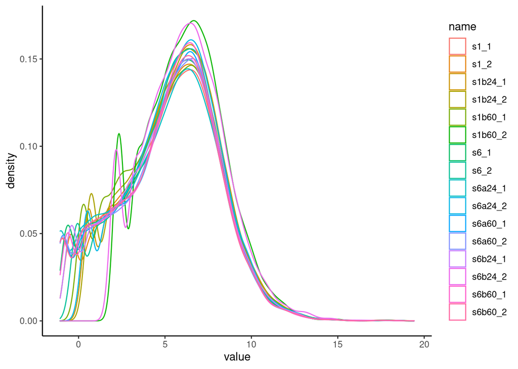

```r
sarscov2_rdf %>% pivot_longer(-1) %>% mutate(value=log2(value)) %>% ggplot(aes(x=value, color=name)) + geom_density()
```

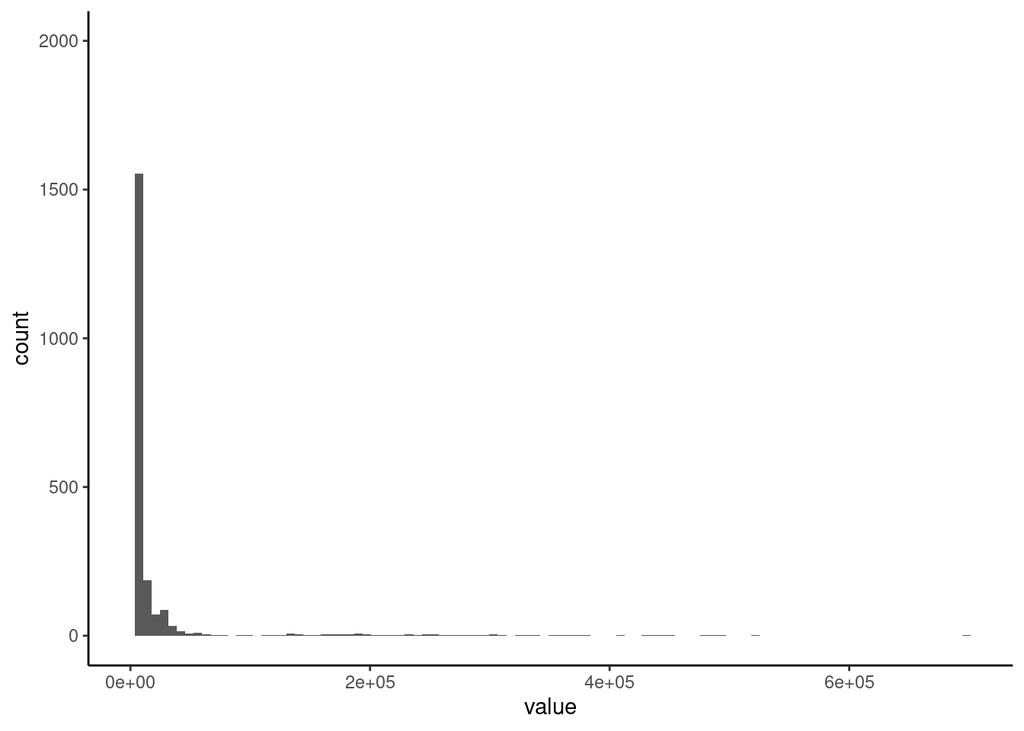

```r
sc2_rnaseq_matrix <- sarscov2_rdf %>% dplyr::select(-1) %>% as.matrix()
sc2_rnaseq_matrix %>% data.frame() %>% pivot_longer(everything()) %>% ggplot(aes(x=value)) + geom_histogram(bins=100) + xlim(0.1, NA) + ylim(0, 2000)
```

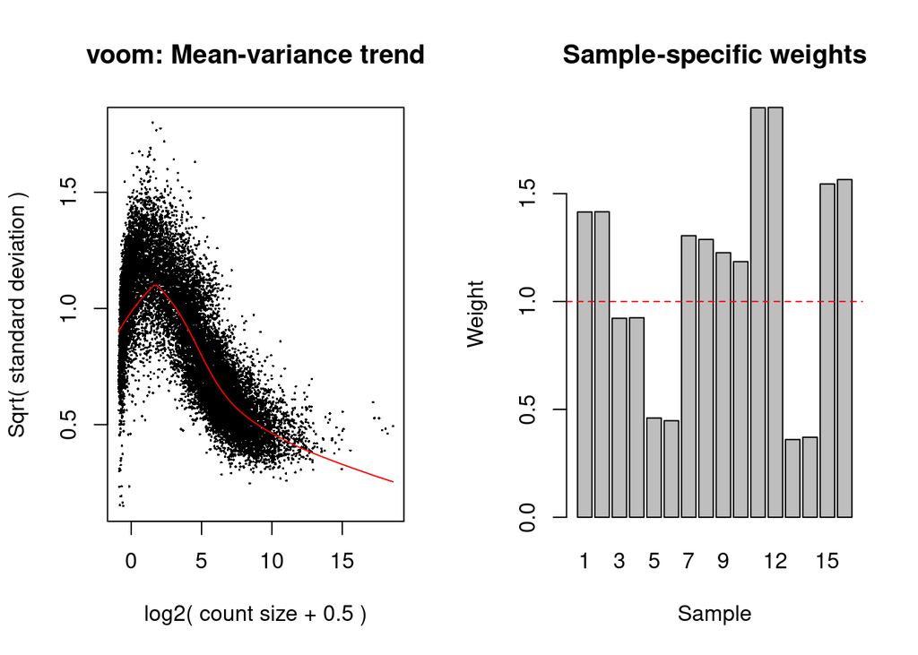

```r
# Create EdgeR DGEList object, replacing NAs with zeroes
sc2_DGE <- edgeR::DGEList(sc2_rnaseq_matrix %>% as.matrix())
# Calculate TMM normalization factors for counts
sc2_DGE <- edgeR::calcNormFactors(sc2_DGE, method = c("TMM"))

# Calculate Voom and Limma
sc2_design_temp <- model.matrix(~0+medium_type_time, data=sarscov2_ddf %>% as.matrix() %>% replace_na("missing") %>% data.frame())
sc2_vwts <- voomWithQualityWeights(sc2_DGE, design=sc2_design_temp, normalize.method="none", plot=TRUE)
```

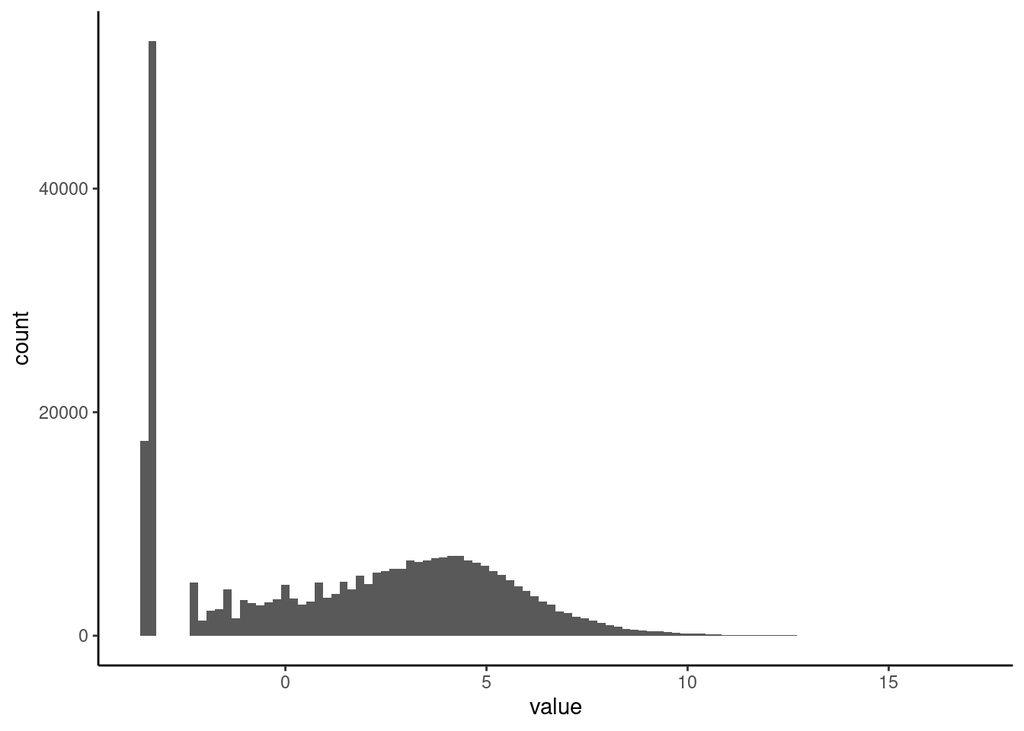

```r
sc2_vwts$E %>% data.frame() %>% pivot_longer(everything()) %>% ggplot(aes(x=value)) + geom_histogram(bins=100)
```

```
##       diff_med_24h.logFC diff_med_24h.AveExpr diff_med_24h.t
## 1              -1.302791          4.505959789      -4.130062
## 7              -1.750553          3.151616836      -4.438331
## 27             -1.877176          1.972778951      -4.407644
## 28             -3.821903         -1.172177579      -4.132505
## 51             -2.907837         -2.155288717      -3.892950
## 69             -2.083112          6.093190573      -6.437380
## 117            -1.560802          3.763738379      -4.040372
## 131            -3.858236          1.962446517      -4.448370
## 132            -3.782952          3.349612743     -12.767504
## 140            -4.210907         -2.259860793      -6.684082
## 170            -1.635278          6.590385827      -8.000082
## 192             1.495697          7.966509540       6.415347
## 246             3.294738         -2.465828763       3.733916
## 297            -1.582645          3.684013486      -5.705213
```

[output cut: 1087 more lines]

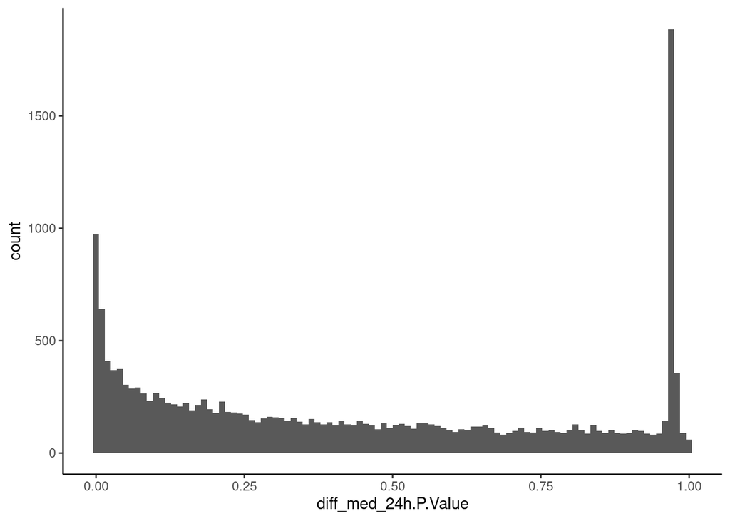

```r
# Perform Limma calculations
sc2_fit <- lmFit(sc2_vwts, sc2_design_temp)

do_limma_contrast <- function(contr, linear_fit, coef, base_name, show_outcome=TRUE) {
  # Retrieve toplist diff medium
  # contr <- makeContrasts(contrast, levels=colnames(coef(sc2_fit)))
  contrast_fit <- contrasts.fit(linear_fit, contr)
  ebayes_contrast_fit <- eBayes(contrast_fit, robust=TRUE)

  stat_adf <- topTable(
    ebayes_contrast_fit,
    adjust="BH",
    coef=coef,
    number=Inf, sort.by = "none") %>%
      `colnames<-`(paste0(base_name, ".", colnames(.)))

  if (show_outcome) {
    print(stat_adf %>% filter(UQ(as.name(sprintf("%s.adj.P.Val", base_name))) < 0.05 & abs(UQ(as.name(sprintf("%s.logFC", base_name)))) > 1))
    print(stat_adf %>% ggplot(aes(x=UQ(as.name(sprintf("%s.P.Value", base_name))))) + geom_histogram(bins=100))
  }

  stat_adf
}

diff_med_24h_sadf <- do_limma_contrast(
  makeContrasts(
    medium_type_timedifferentiation_sarscov2_24h-medium_type_timedifferentiation_control_NA,
    levels=colnames(coef(sc2_fit))
  ),
  sc2_fit,
  "medium_type_timedifferentiation_sarscov2_24h - medium_type_timedifferentiation_control_NA",
  "diff_med_24h"
)
```

```r
exp_med_24h_sadf <- do_limma_contrast(
  makeContrasts(
    medium_type_timeexpansion_sarscov2_24h-medium_type_timeexpansion_control_NA,
    levels=colnames(coef(sc2_fit))
  ),
  sc2_fit,
  "medium_type_timeexpansion_sarscov2_24h - medium_type_timeexpansion_control_NA",
  "exp_med_24h"
)
```

```
##       exp_med_24h.logFC exp_med_24h.AveExpr exp_med_24h.t exp_med_24h.P.Value
## 19            -2.714239          4.98757471     -4.102558        7.361710e-04
## 69             2.263264          6.09319057      5.288578        5.926740e-05
## 83             1.561836          6.19417379      5.127783        8.274512e-05
## 89             2.607194          4.35417424      6.006118        1.389033e-05
## 118           -1.588266          6.29219422     -4.120121        7.086743e-04
## 185            1.256269         10.83964140      6.837295        2.815968e-06
## 287            2.584953          3.79610552      4.081925        7.698530e-04
## 296            1.491402          6.58020960      5.556556        3.421487e-05
## 340           -1.842092          6.64011109     -4.138701        6.807104e-04
## 372           -4.681955         -0.41002876     -4.501116        3.116141e-04
## 390            1.487274          5.37436188      4.442254        3.535737e-04
## 391            1.348867          9.66103047      5.926670        1.625818e-05
## 404            2.099145          4.87890289      4.964157        1.165449e-04
## 421            1.178390          5.70944790      4.100603        7.392973e-04
```

[output cut: 821 more lines]

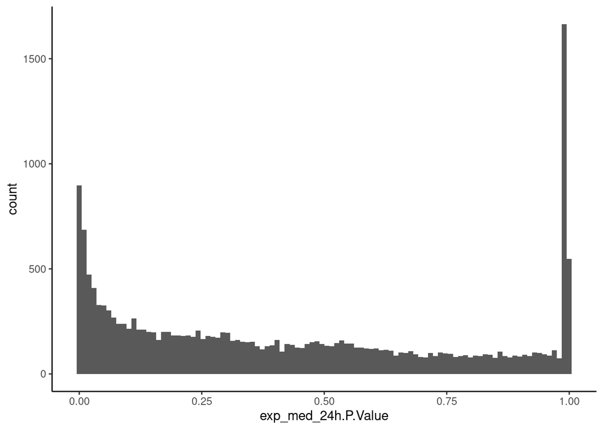

```r
diff_med_60h_sadf <- do_limma_contrast(
  makeContrasts(
    medium_type_timedifferentiation_sarscov2_60h-medium_type_timedifferentiation_control_NA,
    levels=colnames(coef(sc2_fit))
  ),
  sc2_fit,
  "medium_type_timedifferentiation_sarscov2_60h - medium_type_timedifferentiation_control_NA",
  "diff_med_60h"
)
```

```
##       diff_med_60h.logFC diff_med_60h.AveExpr diff_med_60h.t
## 530            -4.652032         0.0761133807      -5.578041
## 596            -5.056832         1.0539859755      -5.208062
## 1025            4.925510        -2.1771305550       5.274639
## 1935            1.596517         3.7726139437       5.474840
## 1948           -7.672994         3.6921690449      -5.324285
## 2533           -1.189850         9.2994625058      -5.965286
## 2813           -5.486486        -2.4693851200      -6.521396
## 2847            5.241881        -1.1816384514       5.623893
## 2911           -5.171960         2.0354570088      -5.755648
## 4625           -1.626887         5.1510102308      -7.672868
## 5400           -4.570033         1.1490887124      -6.180214
## 6864            2.427976         3.2403048934       5.448672
## 7323           -1.284654         8.9455447036      -5.526016
## 7518           -1.550345         9.5289241723      -6.472738
```

[output cut: 45 more lines]

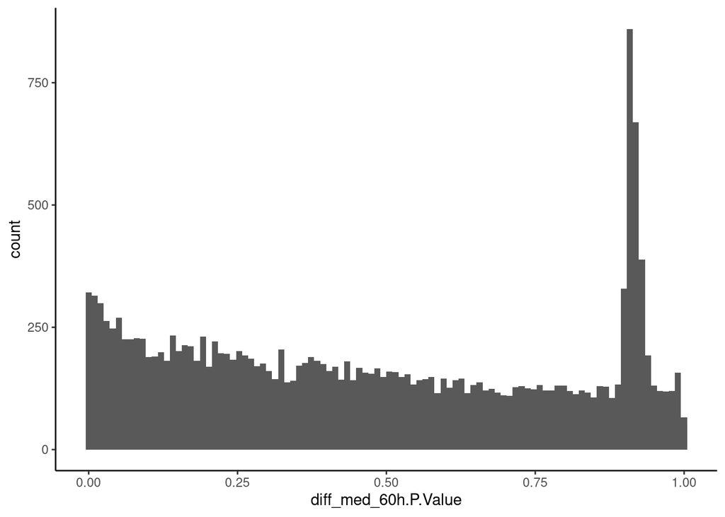

```r
exp_med_60h_sadf <- do_limma_contrast(
  makeContrasts(
    medium_type_timeexpansion_sarscov2_60h-medium_type_timeexpansion_control_NA,
    levels=colnames(coef(sc2_fit))
  ),
  sc2_fit,
  "medium_type_timeexpansion_sarscov2_60h - medium_type_timeexpansion_control_NA",
  "exp_med_60h"
)
```

```
##       exp_med_60h.logFC exp_med_60h.AveExpr exp_med_60h.t exp_med_60h.P.Value
## 26            -2.900046          2.21341151     -4.621670        2.407790e-04
## 28            -3.573989         -1.17217758     -4.257286        5.266830e-04
## 33            -2.506843          1.47914678     -4.010661        8.986077e-04
## 71             3.712599         -0.07764436      4.478816        3.268804e-04
## 138            2.588816          2.64706159      3.903013        1.135411e-03
## 178           -1.440870          6.75531553     -7.787488        5.094652e-07
## 210           -3.529829         -1.88163223     -4.592404        2.563072e-04
## 234           -2.727637          2.71566119     -6.294862        7.894761e-06
## 306            3.793395          1.75538906      4.910221        1.305550e-04
## 311            1.038374          7.25401343      5.957906        1.528101e-05
## 315           -1.240445          5.64029329     -6.280066        8.124459e-06
## 318           -2.923353          3.68552782     -7.821414        4.803638e-07
## 341           -2.371095          1.21165910     -4.327092        4.530251e-04
## 352           -3.787312         -1.97675866     -5.156470        7.794584e-05
```

[output cut: 995 more lines]

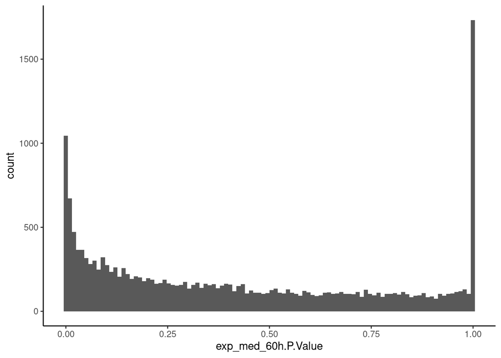

```r
parse_for_omicloupe <- function(raw_df, prefix) {
  raw_df %>%
    janitor::clean_names() %>%
    rename(full_gene=x1, PValue=pvalue, AdjPVal=padj, log2FoldChange=log2fold_change, featureAvg=base_mean) %>%
    rename_at(vars(!matches("^full_gene$")), ~paste0(prefix, ".", .)) %>%
    mutate(idx=gsub("__.*", "", full_gene), chr=gsub(".*__", "", full_gene)) %>% select(idx, chr, full_gene, everything())
}

sarscov2_rna_exp_organoids_df <- read_tsv("../../raw/200710_rna_covid/abc1669-Lamers-Table-S2.tsv") %>%
  parse_for_omicloupe("exp_med_60h_precalc")
sarscov2_rna_diff_organoids_df <- read_tsv("../../raw/200710_rna_covid/abc1669-Lamers-Table-S3.tsv") %>%
  parse_for_omicloupe("diff_org_60h_precalc")
```

## Setup results table

```r
sc2_result_rdf <- cbind(
  idx=sarscov2_rdf$Gene_chromosome %>% gsub("_.*", "", .),
  diff_med_24h_sadf,
  exp_med_24h_sadf,
  diff_med_60h_sadf,
  exp_med_60h_sadf,
  sarscov2_rna_exp_organoids_df %>% dplyr::select(-one_of("idx", "chr", "full_gene")),
  sarscov2_rna_diff_organoids_df %>% dplyr::select(-one_of("idx", "chr", "full_gene")),
  sc2_vwts$E %>% replace_na(0)
)
```

## Output

```r
write_tsv(sc2_result_rdf, path = sprintf("%s/data_rna.tsv", coo_basedir))
write_tsv(sarscov2_ddf, path = sprintf("%s/design_rna.tsv", coo_basedir))
```

# LFQ benchmark dataset

Based on the study “A multicenter study benchmarks software tools for label-free proteome quantification” (doi: doi:10.1038/nbt.3685)

The data is accessed from its ProteomeXchange repository (ID: PXD002952, url: http://proteomecentral.proteomexchange.org/cgi/GetDataset?ID=PXD002952)

## LFQ util functions

```r
classify_protein <- function(protein_labels) {
  if (all(grepl("HUMAN$", protein_labels))) {
    "human"
  }
  else if (all(grepl("YEAS8$", protein_labels))) {
    "yeast"
  }
  else if (all(grepl("ECOLI$", protein_labels))) {
    "ecoli"
  }
  else if (length(protein_labels) > 1) {
    "ambiguous"
  }
  else {
    "unknown"
  }
}

classify_table <- function(rdf, target_col, annot_col) {
  classifications <- rdf[[target_col]] %>%
    lapply(function(raw_string, splitter=";") {
      entries <- raw_string %>% str_split(";") %>% unlist()
      entries <- entries[str_length(entries) > 0]
      classify_protein(entries)
    }) %>% unlist()
  rdf %>% dplyr::mutate(class=classifications) %>% dplyr::select(class, everything())
}

clean_annot <- function(rdf, annot_col) {
  annot_col <- enquo(annot_col)
  rdf %>%
    dplyr::mutate(protein_clean=!!annot_col %>% gsub("1/", "", .) %>% gsub("(\\w)$", "\\1;", .)) %>%
    dplyr::select(protein_clean, everything())
}
```

## Load data

### Filepaths

```r
dia_umpire_fp <- "input_data/1_lfq_workbench/DIAumpire_HYE110_TTOF6600_32fix_PeptideSummary_201604081809.tsv.gz"
openswath_fp <- "input_data/1_lfq_workbench/OpenSWATH_HYE110_TTOF6600_32fixed_160308_feature_alignment.tsv.gz"
peakview_fp <- "input_data/1_lfq_workbench/PeakView_HYE110_TTOF6600_32fixed_160308.xlsx"
skyline_fp <- "input_data/1_lfq_workbench/Skyline_HYE110_TTOF6600_32fixed_160308.tsv.gz"
spectronaut_fp <- "input_data/1_lfq_workbench/Spectronaut_HYE110_TTOF6600_32fixed_160308_Report.tsv.gz"
```

### Setup datasets objects and ddf

```r
lfq_objs <- list()
lfq_objs$du <- list()
lfq_objs$os <- list()
lfq_objs$pv <- list()
lfq_objs$sl <- list()
lfq_objs$sn <- list()


sample_names <- c(
  "lgillet_i160308_001", "lgillet_i160308_003", "lgillet_i160308_010",
  "lgillet_i160308_002", "lgillet_i160308_004", "lgillet_i160308_011"
)

ddf <- data.frame(sample=sample_names, group=c(rep("A", 3), rep("B", 3)), stringsAsFactors = FALSE) %>%
    mutate(level=paste0("Sp", group))
ddf
```

| sample | group | level |
| --- | --- | --- |
| lgillet_i160308_001 | A | SpA |
| lgillet_i160308_003 | A | SpA |
| lgillet_i160308_010 | A | SpA |
| lgillet_i160308_002 | B | SpB |
| lgillet_i160308_004 | B | SpB |
| lgillet_i160308_011 | B | SpB |

### DIA Umpire (du)

```r
lfq_objs$du$raw <- read_tsv(dia_umpire_fp) %>% janitor::clean_names()
lfq_objs$du$rdf <- lfq_objs$du$raw %>%
  dplyr::select(
    peptide=sequence,
    protein=proteins,
    mz=mz,
    charge=charge,
    all_of(paste(sample_names, "ms1", sep="_"))) %>%
  rename_at(vars(matches("^lgillet")), ~gsub("_ms1$", "", .)) %>%
  mutate_at(vars(matches("^lgillet")), ~na_if(., 0))

lfq_objs$du$long <- lfq_objs$du$rdf %>% pivot_longer(matches("^lgillet"), names_to="source", values_to="value")
```

### OpenSWATH (os)

```r
lfq_objs$os$raw <- read_tsv(openswath_fp) %>% janitor::clean_names()
lfq_objs$os$long <- lfq_objs$os$raw %>%
  dplyr::select(
    peptide=peptide_group_label,
    protein=protein_name,
    mz=m_z,
    charge=charge,
    filename,
    value=intensity) %>%
  dplyr::mutate(source=filename %>% gsub(".*/", "", .) %>% gsub("\\..*", "", .) %>% tolower()) %>% dplyr::select(-filename) %>%
  dplyr::select(peptide, protein, mz, charge, source, value)

lfq_objs$os$rdf <- lfq_objs$os$long %>% pivot_wider(names_from = source, values_from = value)
```

### PeakView (pv)

```r
lfq_objs$pv$raw <- read.xlsx(peakview_fp) %>%
  janitor::clean_names()

lfq_objs$pv$rdf <- lfq_objs$pv$raw %>%
  dplyr::select(
    peptide=peptide,
    protein=protein,
    mz=fragment_mz,
    charge=precursor_charge,
    matches("^pedro")) %>%
  dplyr::rename_at(vars(matches("^pedro")), ~gsub(".*fixed_", "", .) %>% gsub("_wiff.*", "", .) %>% tolower())

lfq_objs$pv$long <- lfq_objs$pv$rdf %>%
  pivot_longer(all_of(sample_names), names_to = "source", values_to = "value")
```

### Skyline (sl)

```r
lfq_objs$sl$raw <- read_tsv(skyline_fp, na="0")  %>%
  janitor::clean_names()
lfq_objs$sl$long <- lfq_objs$sl$raw %>%
  dplyr::select(
    peptide=peptide_modified_sequence,
    protein=protein_name,
    mz=precursor_neutral_mass/precursor_charge,
    charge=precursor_charge,
    source=replicate_name,
    value=total_area)

lfq_objs$sl$rdf <- lfq_objs$sl$long %>%
  tidyr::pivot_wider(names_from="source", values_from="value") %>%
  rename_all(~tolower(.))
```

### Spectronaut (sn)

```r
lfq_objs$sn$raw <- read_tsv(spectronaut_fp, na=c("#N/A", "0")) %>%
  janitor::clean_names()
lfq_objs$sn$long <- lfq_objs$sn$raw %>%
      dplyr::select(
    peptide=eg_modified_sequence,
    protein=eg_protein_id,
    mz=fg_prec_mz,
    charge=fg_charge,
    source=r_file_name,
    value=fg_total_peak_area)

lfq_objs$sn$rdf <- lfq_objs$sn$long %>%
  tidyr::pivot_wider(names_from = source, values_from = value) %>%
  rename_all(~tolower(.))
```

## Analysis

### Check numbers

```r
walk(names(lfq_objs), ~message(., " row count: ", lfq_objs[[.]]$rdf %>% nrow()))
```

```
## du row count: 35225
```

```
## os row count: 33237
```

```
## pv row count: 129147
```

```
## sl row count: 90372
```

```
## sn row count: 37040
```

```r
message("---")
walk(names(lfq_objs), ~message(., " unique prots: ", lfq_objs[[.]]$rdf$protein %>% unique() %>% length()))
```

```
## du unique prots: 4181
```

```
## os unique prots: 6780
```

```
## pv unique prots: 4615
```

```
## sl unique prots: 6849
```

```
## sn unique prots: 6225
```

### Check distributions

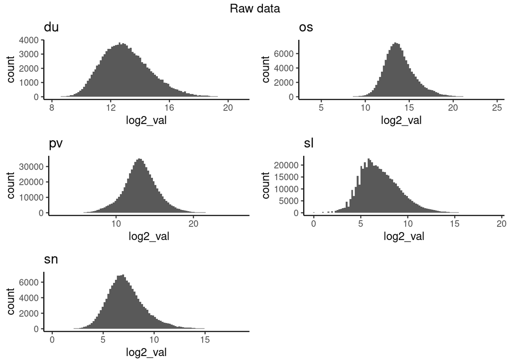

```r
sample_names <- c(
  "lgillet_i160308_001", "lgillet_i160308_003", "lgillet_i160308_010",
  "lgillet_i160308_002", "lgillet_i160308_004", "lgillet_i160308_011"
)

map(
  names(lfq_objs),
  ~lfq_objs[[.]]$long %>% mutate(log2_val=log2(value)) %>% ggplot(aes(x=log2_val)) + geom_histogram(bins=100, na.rm=TRUE) + ggtitle(.)
) %>%
  ggpubr::ggarrange(plotlist = ., nrow=3, ncol=2) %>%
  ggpubr::annotate_figure(top="Raw data")
```

### Perform normalizations

```r
make_normalized_rdf <- function(rdf, samples, transform_func) {
  sdm <- rdf %>% dplyr::select(all_of(samples)) %>% as.matrix()
  adf <- rdf %>% dplyr::select(-all_of(samples))
  sdm_trans <- transform_func(sdm)
  cbind(adf, sdm_trans)
}

lfq_objs <- map(lfq_objs, function(obj, samples) {
  norm_rdf <- make_normalized_rdf(obj$rdf, samples, log2)
  obj$rdf_norm <- norm_rdf
  obj$long_norm <- obj$rdf_norm %>%
    pivot_longer(all_of(samples), names_to="source", values_to="value")
  obj
}, samples=ddf$sample)

names(lfq_objs)
```

```
## [1] "du" "os" "pv" "sl" "sn"
```

### Protein rollup

```r
lfq_objs <- future_map(lfq_objs, function(obj, samples) {

  print("Iteration")
  prot_rdf <- ProteinRollup::protein_rollup(
    obj$rdf_norm$protein,
    obj$rdf_norm %>% dplyr::select(samples) %>% as.matrix(), protein_col_name="protein")

  obj$prot_rdf <- prot_rdf %>%
    classify_table("Protein", "class") %>%
    clean_annot(Protein)

  obj$long_prot <- obj$prot_rdf %>%
    pivot_longer(all_of(samples), names_to="source", values_to="value")

  obj
}, samples=ddf$sample)
```

```
## [1] "Iteration"
```

```
## Note: Using an external vector in selections is ambiguous.
## ℹ Use `all_of(samples)` instead of `samples` to silence this message.
## ℹ See <https://tidyselect.r-lib.org/reference/faq-external-vector.html>.
```

[output not shown]

[output not shown]

[output cut: 266 more lines]

[output not shown]

```
## 585 proteins omitted due to low protein coverage in peptides
```

```
## [1] "Iteration"
```

```
## Note: Using an external vector in selections is ambiguous.
## ℹ Use `all_of(samples)` instead of `samples` to silence this message.
## ℹ See <https://tidyselect.r-lib.org/reference/faq-external-vector.html>.
```

[output not shown]

[output cut: 352 more lines]

[output not shown]

[output not shown]

```
## 1193 proteins omitted due to low protein coverage in peptides
```

```
## [1] "Iteration"
```

```
## Note: Using an external vector in selections is ambiguous.
## ℹ Use `all_of(samples)` instead of `samples` to silence this message.
## ℹ See <https://tidyselect.r-lib.org/reference/faq-external-vector.html>.
```

[output not shown]

[output cut: 208 more lines]

[output not shown]

```
## 0 proteins omitted due to low protein coverage in peptides
```

```
## [1] "Iteration"
```

```
## Note: Using an external vector in selections is ambiguous.
## ℹ Use `all_of(samples)` instead of `samples` to silence this message.
## ℹ See <https://tidyselect.r-lib.org/reference/faq-external-vector.html>.
```

[output not shown]

```
## 0 proteins omitted due to low protein coverage in peptides
```

```
## [1] "Iteration"
```

```
## Note: Using an external vector in selections is ambiguous.
## ℹ Use `all_of(samples)` instead of `samples` to silence this message.
## ℹ See <https://tidyselect.r-lib.org/reference/faq-external-vector.html>.
```

[output not shown]

[output cut: 472 more lines]

[output not shown]

```
## 744 proteins omitted due to low protein coverage in peptides
```

```r
map(names(lfq_objs), ~message(., " prots: ", nrow(lfq_objs[[.]]$prot_rdf)))
```

```
## du prots: 3119
```

```
## os prots: 3956
```

```
## pv prots: 4615
```

```
## sl prots: 4912
```

```
## sn prots: 4141
```

### Visualize distributions of spike-in proteins

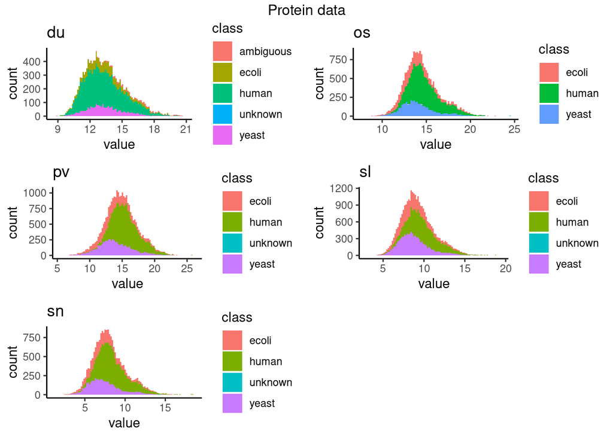

```r
map(
  names(lfq_objs),
  ~lfq_objs[[.]]$long_prot %>% ggplot(aes(x=value, fill=class)) + geom_histogram(bins=100, na.rm=TRUE) + ggtitle(.)
) %>%
  ggpubr::ggarrange(plotlist = ., nrow=3, ncol=2) %>%
  ggpubr::annotate_figure(top="Protein data")
```

### Perform statistical comparisons

#### Functions for LFQ statistics

```r
setup_contrast_object <- function(name, base, levels, formula_string) {
  my_contrasts <- list(levels)
  names(my_contrasts) <- c(name)
  model <- as.formula(formula_string)

  my_contrasts_parsed <- lapply(my_contrasts, function(contrast) {
    paste(paste0(base, contrast), collapse="-")
  }) %>% unlist()

  list(
    name=name,
    model=model,
    contrasts=my_contrasts_parsed,
    group_col=base
  )
}

calculate_limma_contrast <- function(stat_obj, sdf, ddf) {

  model <- as.formula(stat_obj$model)
  model_design <- model.matrix(model, data=ddf)
  fit <- limma::lmFit(sdf, model_design)
  contrasts <- stat_obj$contrasts
  contrast.matrix <- limma::makeContrasts(contrasts=contrasts, levels=model_design)
  fit_contrasts <- contrasts.fit(fit, contrast.matrix)
  fit_bayes <- limma::eBayes(fit_contrasts)
  limma_tables <- lapply(
    seq_len(length(colnames(fit_bayes$coefficients))),
    function(coef) { topTable(
      fit_bayes, coef=coef, number=Inf, sort.by="none", confint = TRUE) }
  )
  names(limma_tables) <- names(contrasts)
  combined_limma_tables <- do.call("cbind", limma_tables)
  combined_limma_tables
}
```

#### Statistical calculations

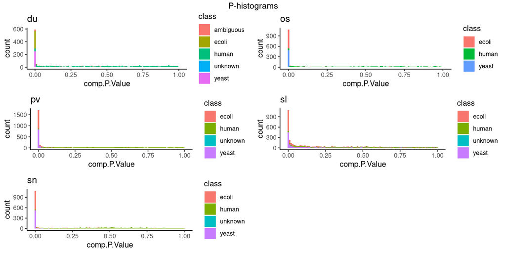

```r
stat_obj <- setup_contrast_object("comp", "group", c("B", "A"), "~0+group")

lfq_objs <- map(lfq_objs, function(obj, samples) {
  sdm <- obj$prot_rdf %>% dplyr::select(all_of(samples)) %>% as.matrix()
  adf <- obj$prot_rdf %>% dplyr::select(-one_of(samples))
  stat_adf <- calculate_limma_contrast(stat_obj, sdm, ddf=ddf)
  obj$prot_stat_rdf <- cbind(adf, stat_adf, sdm)
  obj
}, samples=sample_names)
map(names(lfq_objs), ~lfq_objs[[.]]$prot_stat_rdf %>%
      ggplot(aes(x=comp.P.Value, fill=class)) + geom_histogram(bins=100, na.rm = TRUE) + ggtitle(.)) %>%
        ggpubr::ggarrange(plotlist=., ncol=2, nrow=3) %>% ggpubr::annotate_figure(., top="P-histograms")
```

### Setup joint five-way table (reduced)

```r
common_proteins <- Reduce(intersect, map(lfq_objs, ~.$prot_stat_rdf %>% pull(protein_clean)))
joint_rdfs <- map(lfq_objs, ~.$prot_stat_rdf %>% filter(protein_clean %in% common_proteins) %>% arrange(protein_clean))
joint_rdf_table <- joint_rdfs %>% do.call("cbind", .)
joint_ddf <- map(names(lfq_objs), ~ddf %>% mutate(sample=paste(.x, sample, sep="."), source=.x)) %>% do.call("rbind", .)

print(sprintf("Common proteins: %s", length(common_proteins)))
```

```
## [1] "Common proteins: 2453"
```

### Setup joint five-way table (all proteins)

```r
# map(names(lfq_objs), ~lfq_objs[[.]]$prot_stat_rdf %>% head() %>% rename_at(vars(!matches("protein_clean")), ~paste0(.x, ".", .)))
joint_rdf_table_all <- map(names(lfq_objs), function(pattern) {
  lfq_objs[[pattern]]$prot_stat_rdf %>%
    rename_at(vars(!matches("protein_clean")), ~paste0(pattern, ".", .))
}) %>% Reduce(function(df1, df2) {
  full_join(df1, df2, "protein_clean")
}, .) %>%
  classify_table("protein_clean", "class")
```

## Output

```r
lfq_base_out <- "output_data/lfq"
dir.create(lfq_base_out, recursive = TRUE)
write_tsv(ddf, sprintf("%s/design.tsv", lfq_base_out))
walk(names(lfq_objs), ~write_tsv(lfq_objs[[.]]$prot_stat_rdf, path = sprintf("%s/%s_data.tsv", lfq_base_out, .)))
write_tsv(joint_rdf_table, path=sprintf("%s/joint_data_reduced.tsv", lfq_base_out))
write_tsv(joint_rdf_table_all, path=sprintf("%s/joint_data_full.tsv", lfq_base_out))
write_tsv(joint_ddf, path=sprintf("%s/joint_design.tsv", lfq_base_out))

walk(
    names(lfq_objs),
    ~print(sprintf(
        "Dataset: %s Features: %s",
        .,
        lfq_objs[[.]]$prot_rdf %>% nrow()
    ))
)
```

```
## [1] "Dataset: du Features: 3119"
## [1] "Dataset: os Features: 3956"
## [1] "Dataset: pv Features: 4615"
## [1] "Dataset: sl Features: 4912"
## [1] "Dataset: sn Features: 4141"
```